# Titanic Data Set, BlackForest

Michelle Migdalovich

## R Markdown

**Random Forest:** A random forest was performed to ascertain how well certain variables were at predicting survival rates of the Titanic passengers. Random forest is convenient in that it is able to predict important variables on its own, however for this exercise the main variables were hand-picked.

**Data Set-Up & Cleaning**

```
##   PassengerId       Survived          Pclass
##  Min.   :  1.0   Min.   :0.0000   Min.   :1.000
##  1st Qu.:223.5   1st Qu.:0.0000   1st Qu.:2.000
##  Median :446.0   Median :0.0000   Median :3.000
##  Mean   :446.0   Mean   :0.3838   Mean   :2.309
##  3rd Qu.:668.5   3rd Qu.:1.0000   3rd Qu.:3.000
##  Max.   :891.0   Max.   :1.0000   Max.   :3.000
##
##                                     Name         Sex           Age
##  Abbing, Mr. Anthony                  :  1   female:314   Min.   : 0.42
##  Abbott, Mr. Rossmore Edward          :  1   male  :577   1st Qu.:20.12
##  Abbott, Mrs. Stanton (Rosa Hunt)     :  1                Median :28.00
##  Abelson, Mr. Samuel                  :  1                Mean   :29.70
##  Abelson, Mrs. Samuel (Hannah Wizosky):  1                3rd Qu.:38.00
##  Adahl, Mr. Mauritz Nils Martin       :  1                Max.   :80.00
##  (Other)                              :885                NA's   :177
##      SibSp           Parch             Ticket         Fare
##  Min.   :0.000   Min.   :0.0000   1601    :  7   Min.   :  0.00
##  1st Qu.:0.000   1st Qu.:0.0000   347082  :  7   1st Qu.:  7.91
##  Median :0.000   Median :0.0000   CA. 2343:  7   Median : 14.45
##  Mean   :0.523   Mean   :0.3816   3101295 :  6   Mean   : 32.20
##  3rd Qu.:1.000   3rd Qu.:0.0000   347088  :  6   3rd Qu.: 31.00
##  Max.   :8.000   Max.   :6.0000   CA 2144 :  6   Max.   :512.33
##                                   (Other) :852
##          Cabin     Embarked
##             :687    :  2
##  B96 B98    :  4   C:168
##  C23 C25 C27:  4   Q: 77
##  G6         :  4   S:644
##  C22 C26    :  3
##  D          :  3
##  (Other)    :186
```

This document displays a random forest of a dataset containing data describing the survivors of the Titanic tragedy. The variables used for analyses are Passanger Class (PClass), Age, and Sex.

Passenger Class (PClass): Class of passenger, with one being the 1st class being the highest and 3rd being the lowest

Age: Age of the Passenger. Not all ages were provided, and therefore missing data was filled using a mean data function

Sex: Sex of the passenger

```
##
## Call:
##  randomForest(formula = as.factor(Survived) ~ Pclass + Sex + Age,      data = train, importance = TRUE, ntree = 2000)
##                Type of random forest: classification
##                      Number of trees: 2000
## No. of variables tried at each split: 1
##
##         OOB estimate of  error rate: 18.88%
## Confusion matrix:
##     0   1 class.error
## 0 249  30   0.1075269
## 1  54 112   0.3253012
```

A confusion matrix was generated to ascertain misclassification rate, ROC curves were calculated, as well as Area Under the Curve (AUC)

```
## Confusion Matrix and Statistics
##
##           Reference
## Prediction   0   1
##          0 230  57
##          1  40 119
##
##                Accuracy : 0.7825
##                  95% CI : (0.7413, 0.8199)
##     No Information Rate : 0.6054
##     P-Value [Acc > NIR] : 1.246e-15
##
##                   Kappa : 0.537
##  Mcnemar's Test P-Value : 0.1043
##
##             Sensitivity : 0.8519
##             Specificity : 0.6761
##          Pos Pred Value : 0.8014
##          Neg Pred Value : 0.7484
##              Prevalence : 0.6054
##          Detection Rate : 0.5157
##    Detection Prevalence : 0.6435
##       Balanced Accuracy : 0.7640
##
##        'Positive' Class : 0
##
```

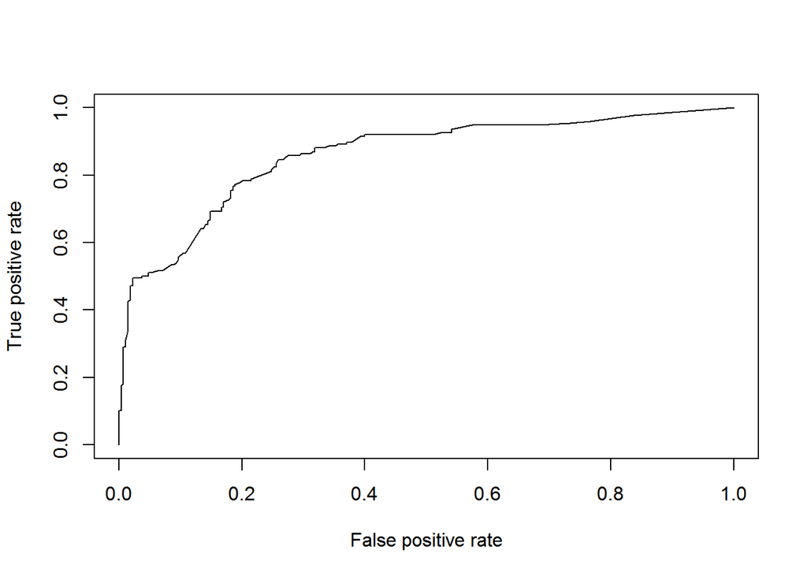

```
## [1] 0.8589752
```

## Plotting the Data

The Random Forest Data was plotted, displaying that sex is a very immportant factor when analyzing “survivors”"

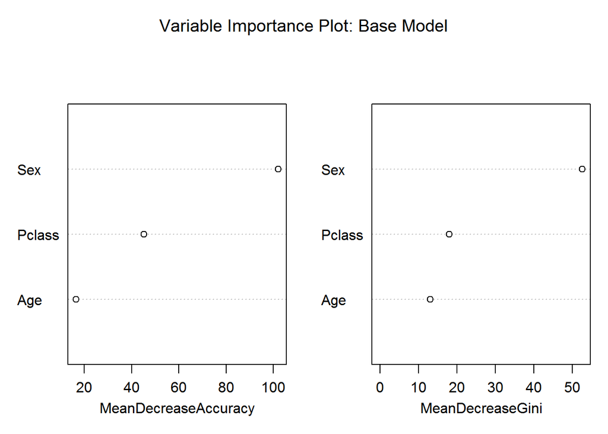

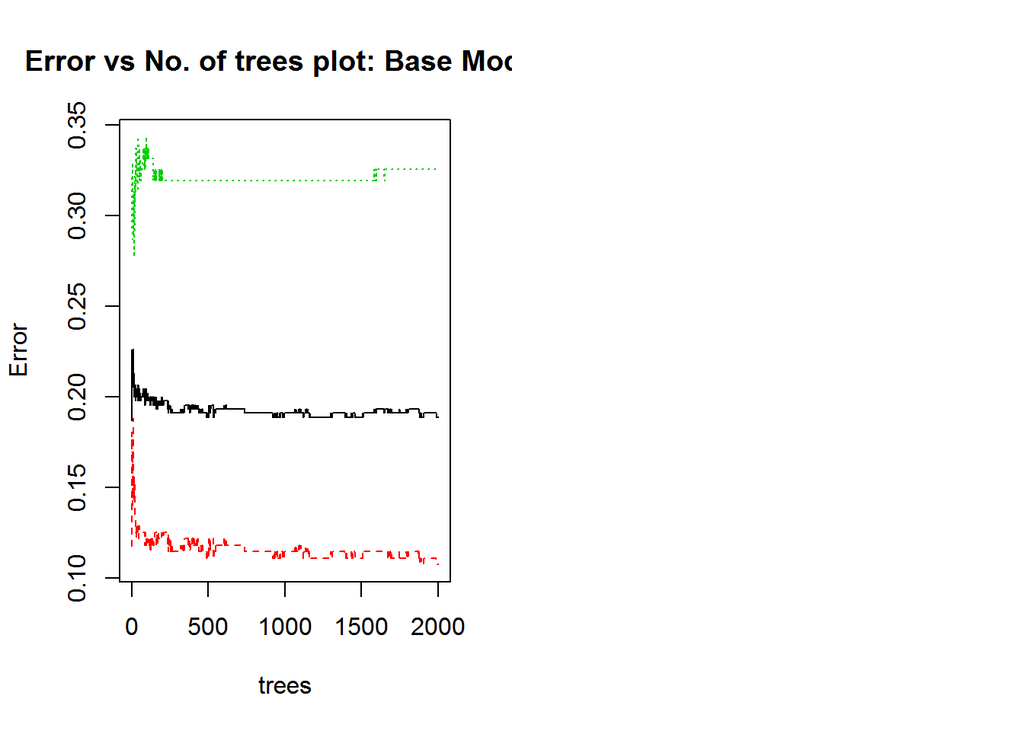

[output not shown]